# Бизнес-показатели маркетплейса

### Анализ пошаговой воронки (step-by-step)

```python
# Рассчитываем пошаговую воронку
funnel_df['conversion_from_previous_%'] = round(funnel_df['users'] / funnel_df['users'].shift(1) * 100,1)
```

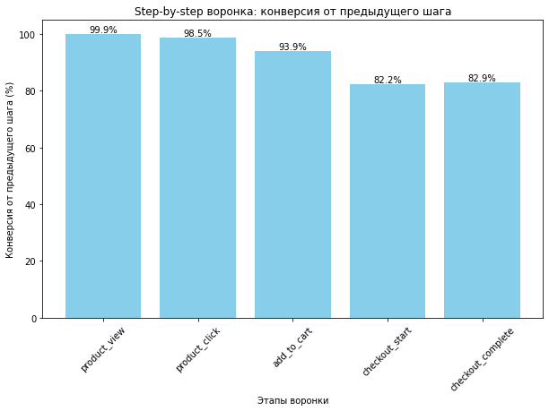

```python
# Визуализируем воронку step-by-step
funnel_df = funnel_df.iloc[1: ] # чтобы не отображать самый первый шаг с Nan

plt.figure(figsize=(10, 6))

bars = plt.bar(funnel_df['step'], funnel_df['conversion_from_previous_%'], color='skyblue')

for bar in bars:
    yval = bar.get_height() # высота столбца=значение
    plt.text(bar.get_x() + bar.get_width()/2, yval, f'{yval}%', verticalalignment='bottom', horizontalalignment='center')

plt.title('Step-by-step воронка: конверсия от предыдущего шага')
plt.ylabel('Конверсия от предыдущего шага (%)')
plt.xticks(rotation=45)
plt.xlabel('Этапы воронки')
plt.show()
```

**Вывод:** Пошаговая воронка демонстрирует проблемы при оформлении заказа на тех же этапах, что и классическая. При переходе от этапа "Добавление в корзину" к этапу "Начало оформления заказа" - теряется 17,8% от предыдущего шага. На этапе "Завершение оформления заказа" теряется еще 17,1%. Проблемы в функционале "checkout".

Необходимо проанализировать воронку по каналам привлечения, но сначала проанализируем другие показатели по каналам.

### Воронка в динамике

Посмотрим на воронку в динамике. Окно атрибуции - 1 месяц.

```python
df = pd.merge(df_events, df_users, on='user_id', how='inner')
```

```python
display(df.head())
```

|  | event_id | user_id | event_date | event_type | os | device | product_name | event_week | event_month | registration_date | age | gender | region | acq_channel | buyer_segment | cohort_week | cohort_month | flag_payer |
| --- | --- | --- | --- | --- | --- | --- | --- | --- | --- | --- | --- | --- | --- | --- | --- | --- | --- | --- |
| 0 | 11 | 2 | 2024-01-02 | page_view | iOS | desktop | NaN | 2024-01-01 | 2024-01-01 | 2024-01-01 | 53 | M | Москва | Email Marketing | rare | 2024-01-01 | 2024-01-01 | 0.0 |
| 1 | 12 | 2 | 2024-01-02 | product_view | iOS | desktop | Тушь для ресниц | 2024-01-01 | 2024-01-01 | 2024-01-01 | 53 | M | Москва | Email Marketing | rare | 2024-01-01 | 2024-01-01 | 0.0 |
| 2 | 13 | 2 | 2024-01-02 | product_click | iOS | desktop | Свитер с капюшоном | 2024-01-01 | 2024-01-01 | 2024-01-01 | 53 | M | Москва | Email Marketing | rare | 2024-01-01 | 2024-01-01 | 0.0 |
| 3 | 14 | 2 | 2024-01-02 | add_to_cart | iOS | desktop | Шкаф-купе | 2024-01-01 | 2024-01-01 | 2024-01-01 | 53 | M | Москва | Email Marketing | rare | 2024-01-01 | 2024-01-01 | 0.0 |
| 4 | 15 | 2 | 2024-01-02 | user_login | iOS | desktop | NaN | 2024-01-01 | 2024-01-01 | 2024-01-01 | 53 | M | Москва | Email Marketing | rare | 2024-01-01 | 2024-01-01 | 0.0 |

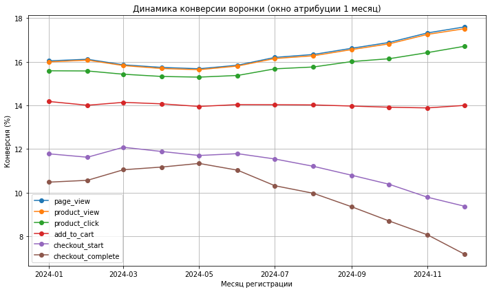

```python
# Список событий воронки
event_list =  ['page_view','product_view','product_click','add_to_cart', 'checkout_start', 'checkout_complete']

attribution_window = 1 ## месяц
df['N_month'] = df['event_date'].dt.month - df['cohort_month'].dt.month
# Фильтруем события в пределах окна атрибуции
df = df.loc[df['N_month'].between(0, attribution_window)]

funnel_dynamic = df.groupby('cohort_month')['event_id'].nunique().reset_index(name='cohort_events')

plt.figure(figsize=(10, 6))

for event in event_list:
    df_event = df.loc[df['event_type'] == event].groupby('cohort_month')['event_id'].nunique().reset_index(name=event)
    funnel_dynamic =  funnel_dynamic.merge(df_event, on='cohort_month', how='left')
    funnel_dynamic[event] = 100* (funnel_dynamic[event] / funnel_dynamic['cohort_events'])
    # Добавляем линию на график
    plt.plot(funnel_dynamic['cohort_month'], funnel_dynamic[event], marker='o', label=event)

# Оформление графика
plt.title('Динамика конверсии воронки (окно атрибуции 1 месяц)')
plt.xlabel('Месяц регистрации')
plt.ylabel('Конверсия (%)')
plt.legend()
plt.grid(True)
plt.tight_layout()
plt.show()
```

**Вывод:** Воронка сигнализирует о проблемах на двух последних этапах, начиная с "Checkout_complete" уже с июня и "Checkout_start" с июля. Показатель падает до конца рассматриваеомого периода. Скорее всего, это говорит о технических проблемах при оформлении заказа.

### Анализ по Каналам привлечения

```python
# Определим список каналов привлечения
list_channel = df_campaign['acq_channel'].unique()
display(list_channel)
```

```
array(['Affiliate', 'Direct', 'Email Marketing', 'Social Media',
       'Google Ads', 'SEO', 'TikTok'], dtype=object)
```

```python
# Подготовим данные
users_orders_months = df_orders.groupby(['user_id', 'order_month'])['total_price'].sum().reset_index()
```

```python
df_orders_users = pd.merge(users_orders_months, df_users, on='user_id', how='left')
```

```python
display(df_orders_users.head())
```

|  | user_id | order_month | total_price | registration_date | age | gender | region | acq_channel | buyer_segment | cohort_week | cohort_month | flag_payer |
| --- | --- | --- | --- | --- | --- | --- | --- | --- | --- | --- | --- | --- |
| 0 | 3 | 2024-01-01 | 87191.23 | 2024-01-01 | 66.0 | F | Санкт-Петербург | Google Ads | regular | 2024-01-01 | 2024-01-01 | 1.0 |
| 1 | 5 | 2024-01-01 | 81820.13 | 2024-01-01 | 58.0 | F | Другие регионы | Google Ads | regular | 2024-01-01 | 2024-01-01 | 1.0 |
| 2 | 5 | 2024-02-01 | 40638.01 | 2024-01-01 | 58.0 | F | Другие регионы | Google Ads | regular | 2024-01-01 | 2024-01-01 | 1.0 |
| 3 | 5 | 2024-03-01 | 18921.66 | 2024-01-01 | 58.0 | F | Другие регионы | Google Ads | regular | 2024-01-01 | 2024-01-01 | 1.0 |
| 4 | 6 | 2024-01-01 | 2319.38 | 2024-01-01 | 53.0 | M | Москва | SEO | medium | 2024-01-01 | 2024-01-01 | 1.0 |

#### Количество привлечённых пользователей для каждого источника

Рассчитаем количество уникальных пользователей по всем каналам привлечения за весь период.

```python
# Группируем по каналу привлечения и считаем количество уникальных пользователей
df_users_channel = df_users.groupby('acq_channel')['user_id'].nunique().reset_index()
```

```python
# Переименуем столбец 'user_id' в 'N_users'
df_users_channel = df_users_channel.rename(columns={'user_id': 'N_users'})
```

```python
# Считаем процент от общего количества
df_users_channel['N_users'] = round((df_users_channel['N_users']/df_users.shape[0]) * 100, 1)
```

```python
# Отсортируем количество пользователей в порядке убывания для наглядности
df_users_channel.sort_values(by='N_users', ascending=True, inplace= True)
```

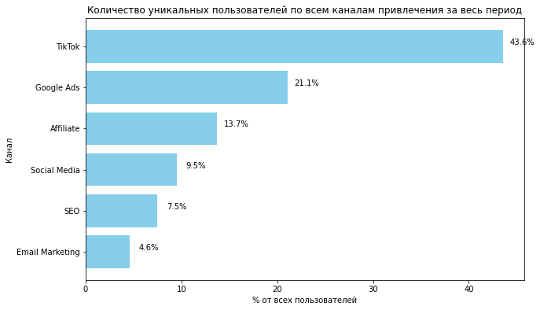

```python
# Визуализируем
plt.figure(figsize=(10, 6))

bars = plt.barh(df_users_channel['acq_channel'], df_users_channel['N_users'], color='skyblue')

for bar in bars:
    width = bar.get_width() # Получаем ширину столбца

    plt.text(width + 2, bar.get_y() + bar.get_height()/2, f'{width}%', verticalalignment='bottom', horizontalalignment='center')
    # комментарий для себя: можно также писать va= ha=

    plt.title('Количество уникальных пользователей по всем каналам привлечения за весь период')
plt.ylabel('Канал')
plt.xlabel('% от всех пользователей')
plt.show()
```

**Вывод**: Самый большой поток пользователей привлекается по каналу TikTok. На втором месте по численности - Google Ads.

#### Затраты по Каналам привлечения

Посчитаем маркетинговые затраты по каналам привлечения общие за год и по месяцам.

```python
# Группируем по каналу привлечения и месяцу и считаем затраты
df_channel = df_campaign.groupby(['acq_channel','spend_month'])['budget'].sum().reset_index()
```

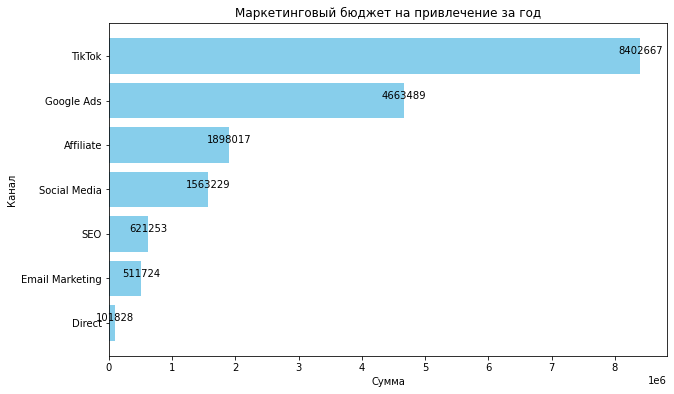

```python
# Визуализируем суммарные расходы за год
plt.figure(figsize=(10, 6))

df_plot = df_channel.groupby('acq_channel')['budget'].sum().reset_index()
df_plot = df_plot.sort_values(by='budget', ascending = True)
bars = plt.barh(df_plot['acq_channel'], df_plot['budget'].astype('int'), color='skyblue')

for bar in bars:
    width = bar.get_width() # Получаем ширину столбца

    plt.text(width + 1, bar.get_y() + bar.get_height()/2, f'{width}', verticalalignment='bottom', horizontalalignment='center')

plt.title('Маркетинговый бюджет на привлечение за год')
plt.ylabel('Канал')
plt.xlabel('Сумма')
plt.show()
```

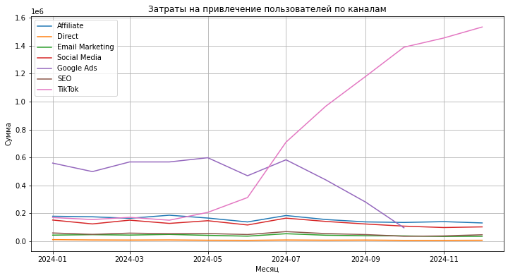

```python
# По месяцам
plt.figure(figsize=(12, 6))
for channel in list_channel:
    df_plot = df_channel.loc[df_channel['acq_channel'] == channel]
    plt.plot(df_plot['spend_month'], df_plot['budget'], label=f'{channel}')

plt.title('Затраты на привлечение пользователей по каналам')
plt.xlabel("Месяц")
plt.ylabel("Сумма")
plt.grid()
plt.legend()
plt.show()
```

**Выводы:** Наблюдаем:

1. С июня - значительный рост затрат на канал TikTok.
2. С июля сокращение затрат на привлечение по каналу Google Ads до полного прекращения в октябре.

#### Выручка по Каналам привлечения

Теперь посмотрим, как соотносится выручка по каналу с затратами на канал и количеством привлеченных пользователей.

Для удобства используем функцию визуализации выручки для разных сегментов.

```python
plt.figure(figsize=(12, 6))
def plot_segment (df, segmentation_attribute):
    # Группировка данных по месяцам и категориям, суммирование выручки
    df_gp = df.groupby(['order_month', segmentation_attribute], as_index=False)['total_price'].sum()
    # Получение всех уникальных сегментов
    segments = df_gp[segmentation_attribute].unique()
    plt.figure(figsize=(12, 6))
    # Для каждого уникального сегмента строим линейный график
    for segment in segments:
        df_plot = df_gp[df_gp[segmentation_attribute] == segment]
        plt.plot(df_plot['order_month'], df_plot['total_price'], label=f'{segment}')

    # Устанавливаем минимальные и максимальные значения для оси y
    plt.ylim(0, df_gp['total_price'].max() * 1.1)

    # Добавляем вертикальную пунктирную линию в августе 2024 — дата начала кризиса.
    plt.axvline(pd.to_datetime("2024-08-01"), color="red", linestyle="--", alpha=0.5)

    # Устанавливаем заголовок
    plt.title(f"Сегментация Выручки по признаку {segmentation_attribute}")

    # Устанавливаем подписи осей
    plt.xlabel("Месяц")
    plt.ylabel("Выручка")
    plt.xticks(rotation=45)

    # Добавляем легенду
    plt.grid()
    plt.legend()
    plt.tight_layout()
    plt.show()
    return
```

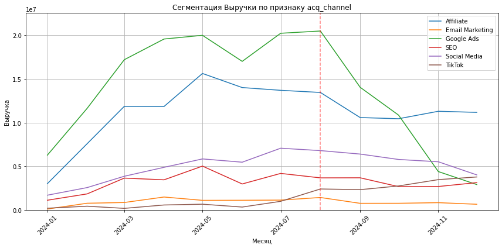

```python
# Выбор признака сегментации
plt.figure(figsize=(12, 6))
plot_segment(df_orders_users, "acq_channel")
```

**Выводы:**

1. Самый значительный контингет по количеству пользователей, канал TikTok, приносит незначительную сумму выручки.
2. Наблюдем аномальное падение на канале Google Ads. Падение выручки по каналу Google Ads практически повторяет график падения общей выручки. Также падение и затем стабилизация заметна на канале Affiliate.
3. С сентября наметился небольшой рост выручки по каналу TikTok.

Причина падения общей выручки - в значительных затратах на привлечение клиентов по каналу TikTok, которые не приосят ожидаемой прибыли, и сокращении привлечения клиентов, приносящих наибольшую прибыль (канал Google Ads).

#### Динамика набора новых пользователей по месяцам и каналам привлечения

Посчитаем MAU. Масштабируем два канала TikTok и Google Ads., т.к. в них зафиксированы самые значительные изменения.

```python
#list_channel = ['TikTok', 'Google Ads']
list_channel = df_campaign['acq_channel'].unique()
```

```python
# Объединим пользователей и события
df_users_events = pd.merge(df_events, df_users, on='user_id', how='left')
```

```python
# группируем по каналу привлечения и считаем количество уникальных пользователей
DAU_channel = df_users_events.groupby(['acq_channel','event_month'])['user_id'].nunique().reset_index()
```

```python
#переименуем столбец
DAU_channel  = DAU_channel.rename(columns={'user_id': 'DAU_channel'})
```

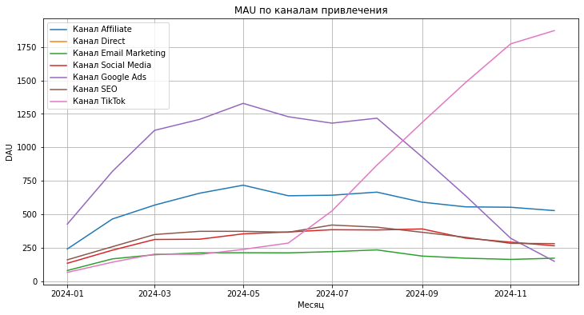

```python
# Строим график по всем каналам привлечения
plt.subplots(figsize=(12,6))

for channel in list_channel:
    df_plot = DAU_channel.loc[DAU_channel['acq_channel'] == channel]
    plt.plot(df_plot['event_month'], df_plot['DAU_channel'], label=f'Канал {channel}')

plt.title('MAU по каналам привлечения')
plt.xlabel('Месяц')
plt.ylabel('DAU')
plt.grid()
plt.legend()
plt.show()
```

**Вывод**: Видим, что изменения в размере аудитории прямо пропорционально маркетинговым затратам на канал.

#### Количество заказов по каналам

```python
# Группируем по месяцу заказа и считаем общее количество заказов и их сумму
orders_users_month = df_orders.groupby(['user_id', 'order_month']).agg({'total_price': 'sum',
                                                     'quantity': 'sum',
                                                     'unit_price': 'mean',
                                                     'order_id' :'count'}).reset_index()
```

```python
# Объединим с Профилем пользователя
df_ = pd.merge(orders_users_month, profiles, on='user_id', how='inner')
```

```python
orders_channel_month = df_.groupby(['acq_channel','order_month'])['order_id'].sum().reset_index()
```

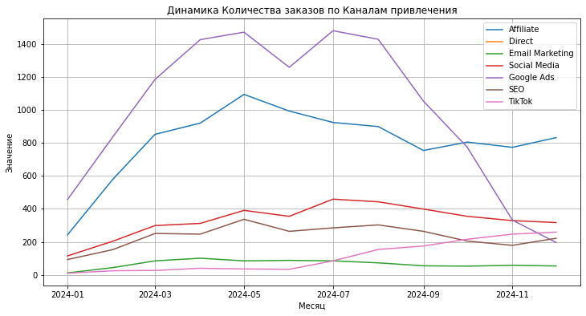

```python
# Визуализируем
plt.subplots(figsize=(12,6))
for channel in list_channel:
    df_plot = orders_channel_month.loc[orders_channel_month['acq_channel'] == channel]
    plt.plot(df_plot['order_month'], df_plot['order_id'], label=f'{channel}')

plt.title('Динамика Количества заказов по Каналам привлечения')
plt.xlabel('Месяц')
plt.ylabel('Значение')
plt.legend()
plt.grid()
plt.show()
```

**Вывод:**

Необходимо проанализировать продуктовые воронки по каналам, особенно по каналу TikTok, вяснив, почему большой объем аудитории не конвертировался в заказы.

#### Классическая воронка по каналам

Рассматривем два канала - TikTok и Google Ads. Ранее в анализе воронок продаж было выяснено, что проблемы существуют в функционале "Checkout", поэтому проверим сразу воронки по каналам и устроствам, возможно, проблемы могут быть не везде.

```python
list_channel = df_campaign['acq_channel'].unique()
```

```python
# Задаем порядок шагов в воронке
funnel_steps = ['page_view','product_view','product_click','add_to_cart', 'checkout_start', 'checkout_complete']
```

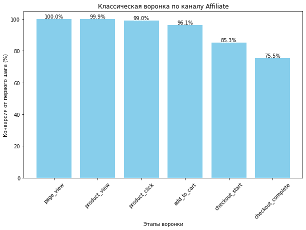

[figure not shown]

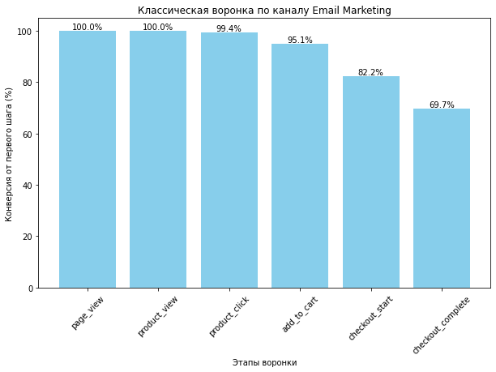

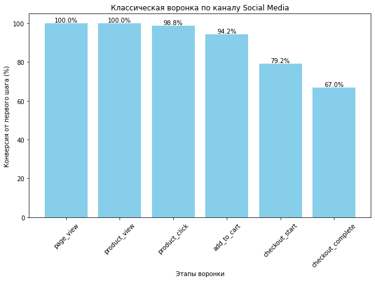

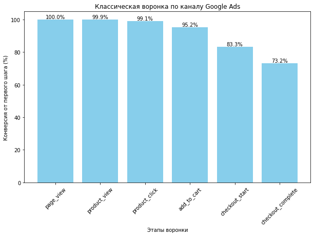

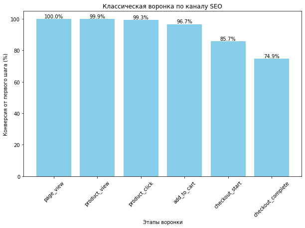

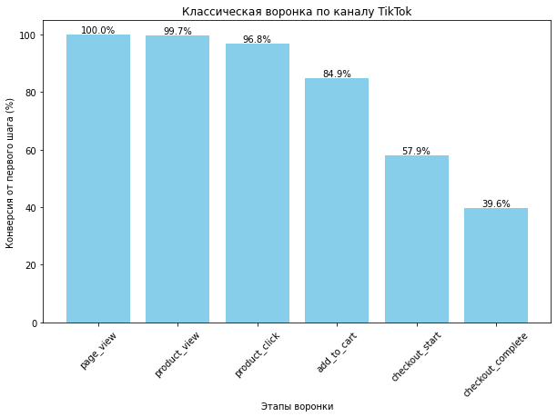

```python
for channel in list_channel:
    report=df_users_events.loc[df_users_events['acq_channel'] == channel]
    # Считаем число уникальных пользователей на каждом шаге
    funnel_counts = report.groupby('event_type')['user_id'].nunique().reindex(funnel_steps)
    # Собираем таблицу воронки
    funnel_df = pd.DataFrame({
               'step': pd.Series(funnel_counts.index),
               'users': pd.Series(funnel_counts.values)})
    # Добавляем конверсии и округляем до 1 знака после запятой
    funnel_df['conversion_from_first_%'] = round((funnel_df['users'] / funnel_df['users'].iloc[0]) *100, 1)
    # Визуализируем классическую воронку
    plt.figure(figsize=(10, 6))

    bars = plt.bar(funnel_df['step'], funnel_df['conversion_from_first_%'], color='skyblue')

    for bar in bars:
        if not np.isnan(bar.get_height()):
            yval = bar.get_height() # высота столбца=значение
            plt.text(bar.get_x() + bar.get_width()/2, yval, f'{yval}%', verticalalignment='bottom', horizontalalignment='center')


    plt.title(f'Классическая воронка по каналу {channel}')
    plt.ylabel('Конверсия от первого шага (%)')
    plt.xlabel('Этапы воронки')
    plt.xticks(rotation=45)
    plt.show()
```

**Выводы:**

1. В воронке по каналу TikTok есть проблемы при переходе к этапу "checkout_start" - 57,9% от первоначального количества, тогда как на других каналах - 79-85%. Соответственно, к последнему шагу переходит всего 39,6% вместо 67-75%.
2. По канаул Direct в воронке совсем нет событий, но деньги на привлечение по этому каналу выделяются.

#### Классическая воронка TikTok по устройствам

```python
# Список устройств
list_device = df_events['device'].unique()
display(list_device)
```

```
array(['desktop', 'mobile', 'tablet'], dtype=object)
```

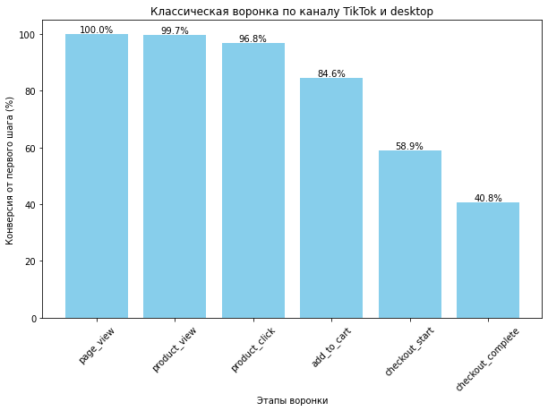

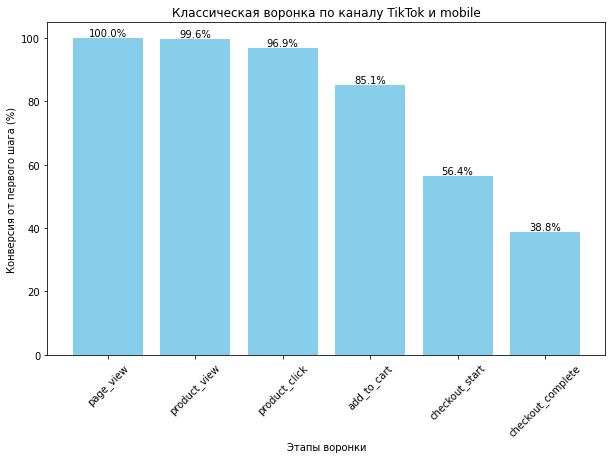

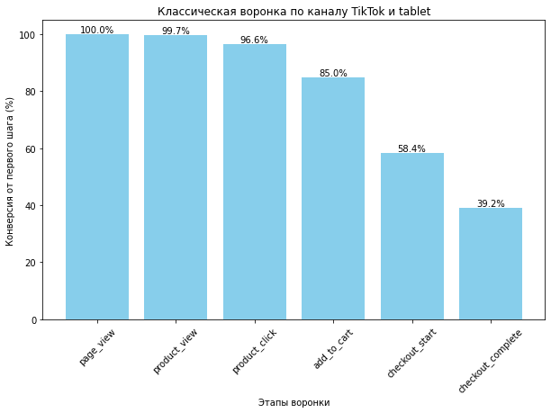

```python
for device in list_device:
    # Выбираем записи по TikTok и устройству
    report=df_users_events.loc[(df_users_events['acq_channel'] == 'TikTok') & (df_users_events['device'] == device)]
    # Считаем число уникальных пользователей на каждом шаге
    funnel_counts = report.groupby('event_type')['user_id'].nunique().reindex(funnel_steps)
    # Собираем таблицу воронки
    funnel_df = pd.DataFrame({
               'step': pd.Series(funnel_counts.index),
               'users': pd.Series(funnel_counts.values)})
    # Добавляем конверсии и округляем до 1 знака после запятой
    funnel_df['conversion_from_first_%'] = round((funnel_df['users'] / funnel_df['users'].iloc[0]) *100, 1)
    # Визуализируем классическую воронку
    plt.figure(figsize=(10, 6))

    bars = plt.bar(funnel_df['step'], funnel_df['conversion_from_first_%'], color='skyblue')

    for bar in bars:
        if not np.isnan(bar.get_height()):
            yval = bar.get_height() # высота столбца=значение
            plt.text(bar.get_x() + bar.get_width()/2, yval, f'{yval}%', verticalalignment='bottom', horizontalalignment='center')


    plt.title(f'Классическая воронка по каналу TikTok и {device}')
    plt.ylabel('Конверсия от первого шага (%)')
    plt.xlabel('Этапы воронки')
    plt.xticks(rotation=45)
    plt.show()
```

**Вывод:** Проблемы с этапами "Checkout_start" и "Checkout_complete" канала TikTok есть на всех устройствах.

### Анализ воронки по операционным системам

```python
# Список устройств
list_os = df_events['os'].unique()
display(list_os)
```

```
array(['iOS', 'Android', 'Windows', 'macOS'], dtype=object)
```

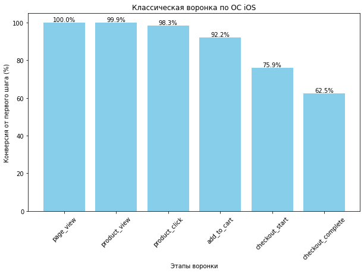

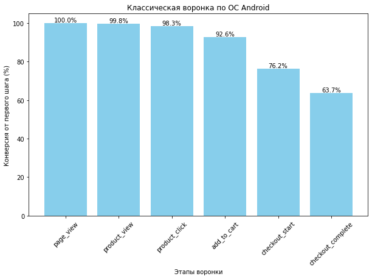

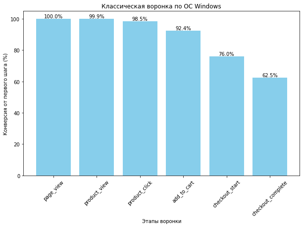

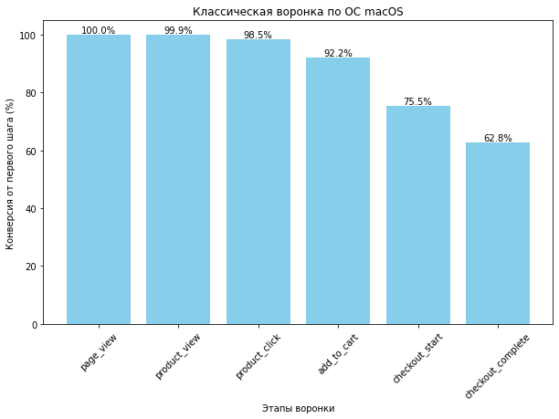

```python
for os in list_os:
    # Выбираем записи по ОС
    report=df_users_events.loc[df_users_events['os'] == os]
    # Считаем число уникальных пользователей на каждом шаге
    funnel_counts = report.groupby('event_type')['user_id'].nunique().reindex(funnel_steps)
    # Собираем таблицу воронки
    funnel_df = pd.DataFrame({
               'step': pd.Series(funnel_counts.index),
               'users': pd.Series(funnel_counts.values)})
    # Добавляем конверсии и округляем до 1 знака после запятой
    funnel_df['conversion_from_first_%'] = round((funnel_df['users'] / funnel_df['users'].iloc[0]) *100, 1)
    # Визуализируем классическую воронку
    plt.figure(figsize=(10, 6))

    bars = plt.bar(funnel_df['step'], funnel_df['conversion_from_first_%'], color='skyblue')

    for bar in bars:
        if not np.isnan(bar.get_height()):
            yval = bar.get_height() # высота столбца=значение
            plt.text(bar.get_x() + bar.get_width()/2, yval, f'{yval}%', verticalalignment='bottom', horizontalalignment='center')


    plt.title(f'Классическая воронка по OC {os}')
    plt.ylabel('Конверсия от первого шага (%)')
    plt.xlabel('Этапы воронки')
    plt.xticks(rotation=45)
    plt.show()
```

**Вывод:** Операционная система не влияет на конверсию в продуктовой воронке, а зависит от канала привлечения (см. анализ выше).

### Анализ Выручки по Регионам

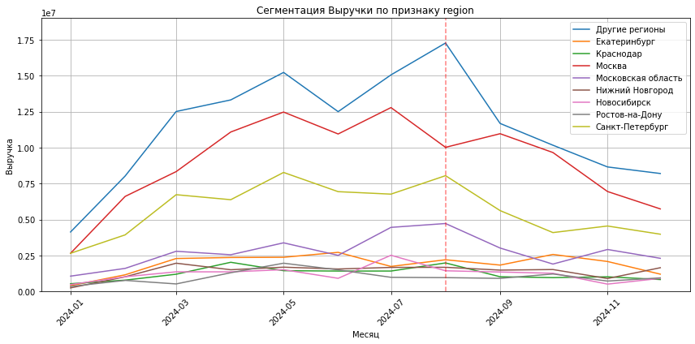

```python
# Выбор признака сегментации
plot_segment(df_orders_users, 'region')
```

### Анализ Выручки по сегменту покупателя

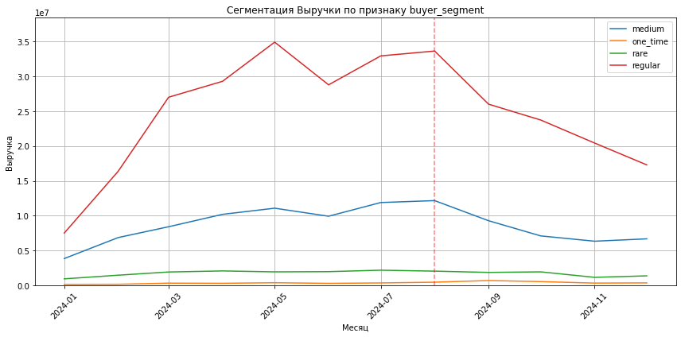

```python
# Выбор признака сегментации
plot_segment(df_orders_users, 'buyer_segment')
```

**Вывод:** Самое значительное падение - у регулярных покупателей, это логично, т.к. их больше всего и их покупки больше всего влияют на выручку. График падения повторяет график падения общей выручки.

### Выручка по комбинации признаков канал + сегмент

Мы локализовали проблему падения выручки по двум каналам: Googel Ads и Affiliate и сегментам покупателей regular и medium. Продолжим анализировать по комбинации признаков канал + сегмент покупателей.

```python
# Создадим отдельный датасет с отфильтрованными данными, оставив только заказы нужных каналов
df_Google_Affiliate_orders = df_orders_users.loc[(df_orders_users['acq_channel'] == 'Google Ads') |
                                                 (df_orders_users['acq_channel'] == 'Affiliate')]
```

```python
# Задаём названия атрибутов для комбинированного признака
first_attr = "acq_channel"
second_attr = "buyer_segment"
combine_attr = f"{first_attr} + {second_attr}"
```

```python
df_Google_Affiliate_orders.loc[:, [combine_attr]] = df_Google_Affiliate_orders[first_attr] + ' - ' + df_Google_Affiliate_orders[second_attr]
```

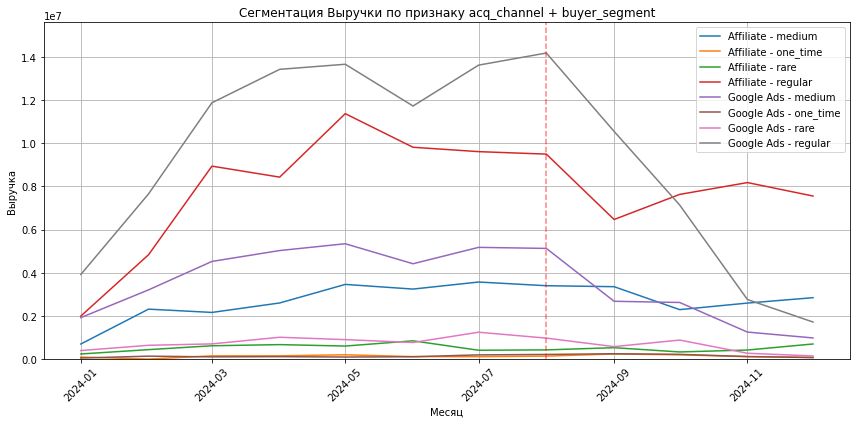

```python
# Вызов функции для комбинированного признака кангал + сегмент
plot_segment(df_Google_Affiliate_orders, combine_attr)
```

**Вывод:** Самое значительное падение - на канале Google Ads и сегмент покупателей regular.

### Анализ товаров. ТОП-10 категорий товаров

```python
# Считаем количество категорий в заказах
df_category = df_orders.groupby('category_name')['quantity'].sum().reset_index()
```

```python
# Общее количество товаров в заказах для расчета %
all_quantity = df_category['quantity'].sum()
all_sum = df_orders['total_price'].sum()
df_category['quantity'] = round((df_category['quantity']/all_quantity) * 100,2)
```

```python
# Отсортируем
df_category = df_category.sort_values(by='quantity', ascending=True)
df_category = df_category.tail(10)
```

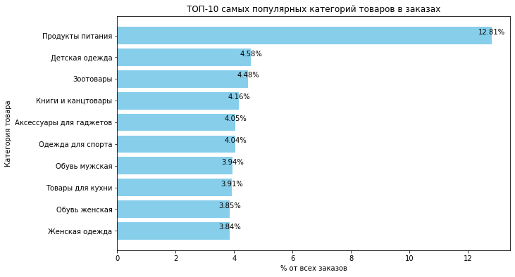

```python
# Визуализируем
plt.figure(figsize=(10, 6))

bars = plt.barh(df_category['category_name'], df_category ['quantity'], color='skyblue')

for bar in bars:
    width = bar.get_width() # Получаем ширину столбца

    plt.text(width, bar.get_y() + bar.get_height()/2, f'{width}%', verticalalignment='bottom', horizontalalignment='center')
    # комментарий для себя: можно также писать va= ha=

    plt.title('ТОП-10 самых популярных категорий товаров в заказах')
plt.ylabel('Категория товара')
plt.xlabel('% от всех заказов')
plt.show()
```

**Вывод:** Самая популярная категория товаров на маркетплейсе - Продукты питания - 12,81% от общего количества товаров.

## Выводы

1. Основная проблема - в сегменте каналов привлечения, где **маркетинговые затраты распределяются неравномерно**:
   - пользователям кнала Google Ads, у которых хорошая конверсия в заказ (по воронке), сокращено финансирование,
   - в тоже время очень большие затраты идут на пользователей по каналу TikTok, которые мало покупают.
   - выделяются деньги на канал Direct, по которму вообще не приходят покупатели

**Рекомендация:** перераспределить затраты на каналы: убрать затраты на Direct, сократить затраты на TikTok в пользу Google Ads.

2. Анализ продуктовых воронок показал, что основная масса пользователей **теряется на переходе к этапу "Checkout_start"**. Особенно это касается канала **TikTok**, причем на всех типах устройств. Что влечет снижение конверсии в заказ.

**Рекомендация:** проверить технически что не так, и почему это происходит.

3. Сегмент покупателей, который больше всего влияет на выручку - это регулярные и medium покупатели канала Google Ads.

**Рекомендация:** регулярным покупателям напоминать сделать очередную покупку, предлагать акции.

4. Анализ категорий товаров показал, что самой популярной и часто заказываемой категорий товара являются "Продукты питания".

**Рекомендация:** провести дополнительный анализ для расширения ассортимента в этой категории.